# Mendelian Randomization Analysis

Dr. Shea Andrews

2018-10-12

## Instrumental Variables

**SNP Inclusion:** SNPS associated with at a p-value threshold of p < 5e-6 were included in this analysis.

**LD Clumping:** For standard two sample MR it is important to ensure that the instruments for the exposure are independent. LD clumping was performed in PLINK using the EUR samples from the 1000 Genomes Project to estimate LD between SNPs, and, amongst SNPs that have an LD above a given threshold, retain only the SNP with the lowest p-value. A clumping window of 250kb, r2 of 0.1 and significance level of 1 was used for the index and secondary SNPs.

**Proxy SNPs:** Where SNPs were not available in the outcome GWAS, the EUR thousand genomes was queried to identify potential proxy SNPs that are in linkage disequilibrium (r2 > 0.8) of the missing SNP.

### Exposure: LOAD

*Late Onset Alzheimer’s disease* [Lambert et al 2013](https://doi.org/10.1038/ng.2802): The International Genomics of Alzheimers Project (IGAP) is a meta-analysis of 4 previously published GWAS datasets: the European Alzheimers Disease Imitative (EADI), the Alzheimer Disease Genetics Consortium (ADGC), Cohorts for Heart and Aging Research in Genomic Epidemiology (CHARGE), and Genetic and Environmental Risk in AD (GERAD) and includes a sample of 17,008 LOAD cases and 37,154 cognitively normal elder controls. Participants in IGAP were of European ancestry, the average age was 71 and 58.4% of participants were women.

**Table 1:** Independent SNPs associated with LOAD

| SNP | CHR | POS | Effect_allele | Non_Effect_allele | EAF | Beta | SE | P | r2 | N |
| --- | --- | --- | --- | --- | --- | --- | --- | --- | --- | --- |
| rs1410397 | 1 | 193627682 | C | T | 0.5348 | 0.0766 | 0.0160 | 1.616e-06 | 0.002919568 | 54162 |
| rs1752684 | 1 | 207747296 | A | G | 0.1987 | 0.1541 | 0.0196 | 3.653e-15 | 0.007561854 | 54162 |
| rs4147104 | 1 | 207882194 | A | G | NA | 0.0774 | 0.0167 | 3.421e-06 | NA | 54162 |
| rs4663105 | 2 | 127891427 | C | A | 0.5664 | 0.1837 | 0.0172 | 1.001e-26 | 0.016575278 | 54162 |
| rs745717 | 2 | 127893897 | C | G | 0.0992 | 0.2008 | 0.0288 | 2.879e-12 | 0.007206053 | 54162 |
| rs62273237 | 3 | 128310107 | T | C | 0.4035 | 0.0748 | 0.0160 | 2.768e-06 | 0.002693315 | 54162 |
| rs7657553 | 4 | 11723235 | A | G | 0.2797 | 0.0830 | 0.0172 | 1.462e-06 | 0.002775825 | 54162 |
| rs190982 | 5 | 88223420 | G | A | 0.6141 | -0.0799 | 0.0170 | 2.547e-06 | 0.003025781 | 54162 |
| rs2878896 | 5 | 139710507 | G | A | 0.5077 | 0.0833 | 0.0156 | 9.219e-08 | 0.003468622 | 54162 |
| rs28895055 | 6 | 32417185 | G | A | 0.8762 | 0.1193 | 0.0253 | 2.299e-06 | 0.003087698 | 54162 |

[output cut: 79 more lines]

### Outcome: Depression Symptoms

*Broad Depression Symptoms* [Howard et al 2018](https://doi.org/10.1038/s41467-018-03819-3): Using up to 322,580 UK Biobank participants, broad depression was based on self-reported help-seeking behavior for mental health difficulties from either a general practitioner or psychiatrist.

**Table 2:** SNPs associated with LOAD avaliable in Depression Symptoms

| SNP | CHR | POS | Effect_allele | Non_Effect_allele | EAF | Beta | SE | P | r2 | N |
| --- | --- | --- | --- | --- | --- | --- | --- | --- | --- | --- |
| rs1410397 | 1 | 193627682 | T | C | 0.5448590 | 1.2589e-03 | 0.0011820 | 0.2868269798 | 7.860362e-07 | 322580 |
| rs1752684 | 1 | 207747296 | G | A | 0.8200830 | -9.5515e-04 | 0.0015318 | 0.5329420646 | 2.692174e-07 | 322580 |
| rs4147104 | NA | NA | NA | NA | NA | NA | NA | NA | NA | NA |
| rs4663105 | 2 | 127891427 | C | A | 0.4187910 | -7.3082e-04 | 0.0012045 | 0.5440264310 | 2.600043e-07 | 322580 |
| rs745717 | 2 | 127893897 | C | G | 0.0891575 | 2.2155e-03 | 0.0021071 | 0.2930690793 | 7.972136e-07 | 322580 |
| rs62273237 | 3 | 128310107 | C | T | 0.5927500 | -3.6233e-04 | 0.0012001 | 0.7627285448 | 6.338277e-08 | 322580 |
| rs7657553 | 4 | 11723235 | G | A | 0.7255840 | 2.3843e-03 | 0.0013203 | 0.0709251071 | 2.263857e-06 | 322580 |
| rs190982 | 5 | 88223420 | A | G | 0.6012350 | -2.6768e-03 | 0.0012192 | 0.0281319606 | 3.435762e-06 | 322580 |
| rs2878896 | 5 | 139710507 | A | G | 0.5226060 | 3.0247e-03 | 0.0011824 | 0.0105293121 | 4.565054e-06 | 322580 |
| rs28895055 | NA | NA | NA | NA | NA | NA | NA | NA | NA | NA |

[output cut: 79 more lines]

**Table 3:** Proxy SNPs for Depression Symptoms

| query_snp_rsid | rsID | ld.r2 | Dprime | ref.proxy | alt.proxy | CHR | POS | Effect_allele.proxy | Non_Effect_allele.proxy | EAF | Beta | SE | P | r2 | N | ref | alt | Effect_allele | Non_Effect_allele |
| --- | --- | --- | --- | --- | --- | --- | --- | --- | --- | --- | --- | --- | --- | --- | --- | --- | --- | --- | --- |
| rs111679419 | NA | NA | NA | NA | NA | NA | NA | NA | NA | NA | NA | NA | NA | NA | NA | NA | NA | NA | NA |
| rs138607350 | NA | NA | NA | NA | NA | NA | NA | NA | NA | NA | NA | NA | NA | NA | NA | NA | NA | NA | NA |
| rs28366259 | NA | NA | NA | NA | NA | NA | NA | NA | NA | NA | NA | NA | NA | NA | NA | NA | NA | NA | NA |
| rs28895055 | rs13199014 | 0.87 | 1 | A | C | 6 | 32419012 | C | A | 0.160423 | 0.0036877 | 0.0016038 | 0.02148325 | 3.663265e-06 | 322580 | A | G | G | A |
| rs34583389 | NA | NA | NA | NA | NA | NA | NA | NA | NA | NA | NA | NA | NA | NA | NA | NA | NA | NA | NA |
| rs41269974 | NA | NA | NA | NA | NA | NA | NA | NA | NA | NA | NA | NA | NA | NA | NA | NA | NA | NA | NA |
| rs4147104 | NA | NA | NA | NA | NA | NA | NA | NA | NA | NA | NA | NA | NA | NA | NA | NA | NA | NA | NA |
| rs9272561 | NA | NA | NA | NA | NA | NA | NA | NA | NA | NA | NA | NA | NA | NA | NA | NA | NA | NA | NA |

## Data harmonization

Harmonize the exposure and outcome datasets so that the effect of a SNP on the exposure and the effect of that SNP on the outcome correspond to the same allele. The harmonise_data function from the TwoSampleMR package can be used to perform the harmonization step, by default it try’s to infer the forward strand alleles using allele frequency information. EAF were not availbe in the IGAP summary statisitics, as such the allele frequencies reported in the AAOS anaylsis were used.

**Table 4:** Harmonized LOAD and Depression Symptoms datasets

| SNP | effect_allele.exposure | other_allele.exposure | effect_allele.outcome | other_allele.outcome | beta.exposure | beta.outcome | eaf.exposure | eaf.outcome | remove | palindromic | ambiguous | id.outcome | se.outcome | pval.outcome | outcome | mr_keep.outcome | pval_origin.outcome | se.exposure | pval.exposure | exposure | mr_keep.exposure | pval_origin.exposure | id.exposure | action | mr_keep | samplesize.outcome | mrpresso_RSSobs | mrpresso_pval | mrpresso_keep |
| --- | --- | --- | --- | --- | --- | --- | --- | --- | --- | --- | --- | --- | --- | --- | --- | --- | --- | --- | --- | --- | --- | --- | --- | --- | --- | --- | --- | --- | --- |
| rs10143128 | C | T | C | T | 0.2091 | 2.1977e-03 | 0.9437 | 0.0701580 | FALSE | FALSE | FALSE | jqltXP | 0.0023175 | 0.3429809508 | dep | TRUE | reported | 0.0393 | 1.004e-07 | load | TRUE | reported | xBSKBt | 2 | TRUE | NA | 4.791445e-06 | 1.0000 | TRUE |
| rs10401176 | T | C | T | C | -0.2139 | 3.5506e-03 | 0.1204 | 0.1255460 | FALSE | FALSE | FALSE | jqltXP | 0.0017886 | 0.0471302778 | dep | TRUE | reported | 0.0317 | 1.508e-11 | load | TRUE | reported | xBSKBt | 2 | TRUE | NA | 1.295983e-05 | 1.0000 | TRUE |
| rs10415949 | G | A | G | A | -0.0901 | 1.1110e-03 | 0.7613 | 0.2351910 | FALSE | FALSE | FALSE | jqltXP | 0.0013990 | 0.4271200906 | dep | TRUE | reported | 0.0184 | 1.024e-06 | load | TRUE | reported | xBSKBt | 2 | TRUE | NA | 1.258715e-06 | 1.0000 | TRUE |
| rs10426759 | A | G | A | G | 0.0787 | -1.9443e-04 | 0.5239 | 0.5260990 | FALSE | FALSE | FALSE | jqltXP | 0.0011794 | 0.8690564756 | dep | TRUE | reported | 0.0168 | 2.844e-06 | load | TRUE | reported | xBSKBt | 2 | TRUE | NA | 4.085968e-08 | 1.0000 | TRUE |
| rs10509088 | T | C | T | C | -0.1813 | 2.3500e-03 | 0.0444 | 0.0424695 | FALSE | FALSE | FALSE | jqltXP | 0.0029169 | 0.4204457821 | dep | TRUE | reported | 0.0387 | 2.786e-06 | load | TRUE | reported | xBSKBt | 2 | TRUE | NA | 5.625748e-06 | 1.0000 | TRUE |
| rs10792832 | A | G | A | G | -0.1297 | -3.3374e-04 | 0.3563 | 0.3717080 | FALSE | FALSE | FALSE | jqltXP | 0.0012159 | 0.7837183221 | dep | TRUE | reported | 0.0161 | 6.534e-16 | load | TRUE | reported | xBSKBt | 2 | TRUE | NA | 1.049983e-07 | 1.0000 | TRUE |
| rs10808026 | A | C | A | C | -0.1393 | 7.8189e-04 | 0.1883 | 0.2157800 | FALSE | FALSE | FALSE | jqltXP | 0.0014367 | 0.5862731434 | dep | TRUE | reported | 0.0206 | 1.417e-11 | load | TRUE | reported | xBSKBt | 2 | TRUE | NA | 6.383424e-07 | 1.0000 | TRUE |
| rs10856 | T | G | T | G | 0.3611 | -1.9031e-03 | 0.0727 | 0.0764663 | FALSE | FALSE | FALSE | jqltXP | 0.0022107 | 0.3893229451 | dep | TRUE | reported | 0.0437 | 1.484e-16 | load | TRUE | reported | xBSKBt | 2 | TRUE | NA | 3.867066e-06 | 1.0000 | TRUE |
| rs111278892 | G | C | G | C | 0.1867 | 4.6655e-03 | 0.8544 | 0.8456170 | FALSE | TRUE | FALSE | jqltXP | 0.0016297 | 0.0041985565 | dep | TRUE | reported | 0.0371 | 4.813e-07 | load | TRUE | reported | xBSKBt | 2 | TRUE | NA | 2.194068e-05 | 0.3116 | TRUE |
| rs11218343 | C | T | C | T | -0.2697 | -9.7794e-07 | 0.9605 | 0.0372274 | FALSE | FALSE | FALSE | jqltXP | 0.0031108 | 0.9997491648 | dep | TRUE | reported | 0.0410 | 4.976e-11 | load | TRUE | reported | xBSKBt | 2 | TRUE | NA | 5.641406e-10 | 1.0000 | TRUE |

[output cut: 72 more lines]

## MR Results

To obtain an overall estimate of causal effect, the SNP-exposure and SNP-outcome coefficients were combined in 1) a fixed-effects meta-analysis using an inverse-variance weighted approach (IVW); 2) a Weighted Median approach; 3) Weighted Mode approach and 4) Egger Regression.

[**IVW**](https://doi.org/10.1002/gepi.21758) is equivalent to a weighted regression of the SNP-outcome coefficients on the SNP-exposure coefficients with the intercept constrained to zero. This method assumes that all variants are valid instrumental variables based on the Mendelian randomization assumptions. The causal estimate of the IVW analysis expresses the causal increase in the outcome (or log odds of the outcome for a binary outcome) per unit change in the exposure. [**Weighted median MR**](https://doi.org/10.1002/gepi.21965) allows for 50% of the instrumental variables to be invalid. [**MR-Egger regression**](https://doi.org/10.1093/ije/dyw220) allows all the instrumental variables to be subject to direct effects (i.e. horizontal pleiotropy), with the intercept representing bias in the causal estimate due to pleiotropy and the slope representing the causal estimate. [**Weighted Mode**](https://doi.org/10.1093/ije/dyx102) gives consistent estimates as the sample size increases if a plurality (or weighted plurality) of the genetic variants are valid instruments.

Table 5 presents the MR causal estimates of genetically predicted LOAD on Depression Symptoms.

**Table 5** MR causaul estimates for LOAD on Depression Symptoms

| id.exposure | id.outcome | outcome | exposure | method | nsnp | b | se | pval |
| --- | --- | --- | --- | --- | --- | --- | --- | --- |
| xBSKBt | jqltXP | dep | load | Inverse variance weighted (fixed effects) | 81 | 1.108258e-04 | 0.0007623203 | 0.8844112 |
| xBSKBt | jqltXP | dep | load | Weighted median | 81 | -6.784070e-04 | 0.0013636780 | 0.6188483 |
| xBSKBt | jqltXP | dep | load | Weighted mode | 81 | -5.864232e-04 | 0.0012375737 | 0.6368982 |
| xBSKBt | jqltXP | dep | load | MR Egger | 81 | -3.218736e-05 | 0.0013662786 | 0.9812642 |

Figure 1 illustrates the SNP-specific associations with LOAD versus the association in Depression Symptoms and the corresponding MR estimates.

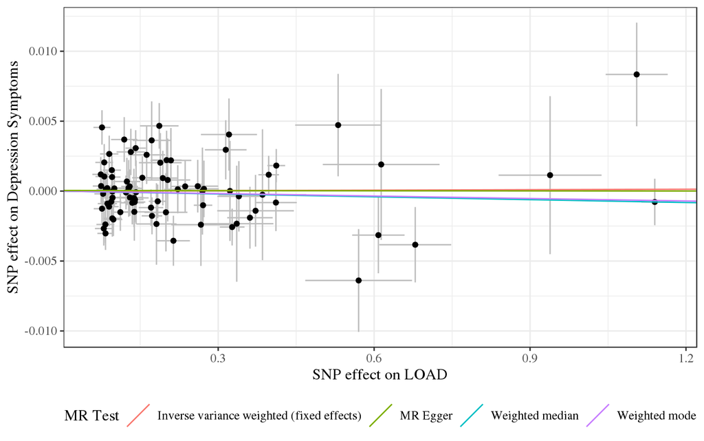

Fig. 1: Scatterplot of SNP effects for the association of the Exposure on the Outcome

## Pleiotropy

Figure 2 shows a funnel plot displaying the MR estimates of individual genetic variants against their precession. Aysmmetry in the funnel plot may arrise due to some genetic variants having unusally strong effects on the outcome, which is indicative of directional pleiotropy.

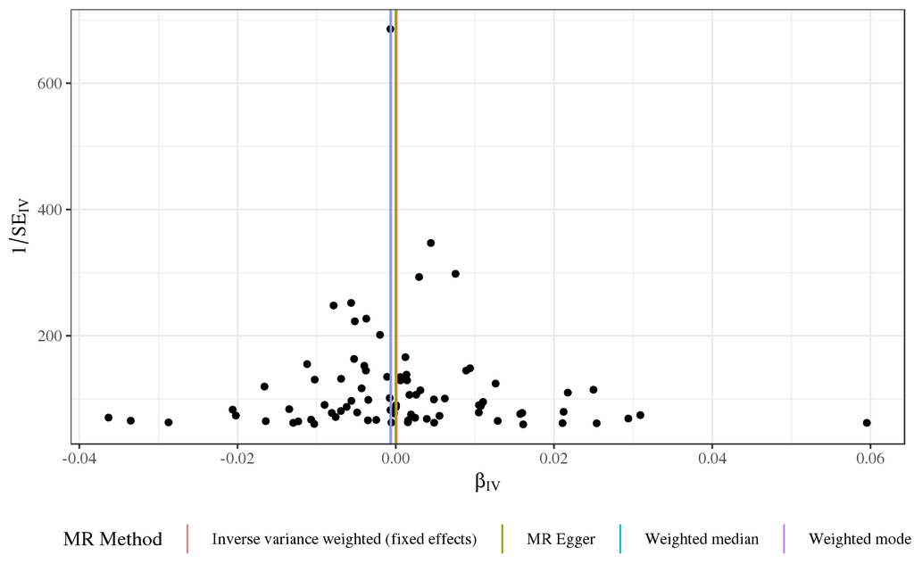

Fig. 2: Funnel plot of the MR causal estimates against their precession

A Cochrans Q heterogeneity test can be used to formaly assesse for the presence of heterogenity (Table 6).

**Table 6:** Heterogenity Tests

| id.exposure | id.outcome | outcome | exposure | method | Q | Q_df | Q_pval |
| --- | --- | --- | --- | --- | --- | --- | --- |
| xBSKBt | jqltXP | dep | load | MR Egger | 114.2491 | 79 | 0.005837286 |
| xBSKBt | jqltXP | dep | load | Inverse variance weighted | 114.2779 | 80 | 0.007165515 |

The intercept of the MR-Regression model captures the average pleitropic affect across all genetic variants (Table 7).

**Table 7:** MR Egger test for directional pleitropy

| id.exposure | id.outcome | outcome | exposure | egger_intercept | se | pval |
| --- | --- | --- | --- | --- | --- | --- |
| xBSKBt | jqltXP | dep | load | 4.420896e-05 | 0.000313162 | 0.8880953 |

Pleiotropy was also assesed using Mendelian Randomization Pleiotropy RESidual Sum and Outlier [(MR-PRESSO)](https://doi.org/10.1038/s41588-018-0099-7), that allows for the evlation of evaluation of horizontal pleiotropy in a standared MR model (Table 8). MR-PRESSO performs a global test for detection of horizontal pleiotropy and correction of pleiotropy via outlier removal (Table 9).

**Table 8:** MR-PRESSO Global Test for pleitropy

| id.exposure | id.outcome | outcome | exposure | n_outliers | RSSobs | pval |
| --- | --- | --- | --- | --- | --- | --- |
| xBSKBt | jqltXP | dep | load | 1 | 117.358 | 0.0091 |

**Table 9:** MR Estimates after MR-PRESSO outlier removal

| id.exposure | id.outcome | outcome | exposure | method | nsnp | b | se | pval |
| --- | --- | --- | --- | --- | --- | --- | --- | --- |
| xBSKBt | jqltXP | dep | load | Inverse variance weighted (fixed effects) | 80 | -2.277403e-05 | 0.0007631768 | 0.9761938 |
| xBSKBt | jqltXP | dep | load | Weighted median | 80 | -6.784784e-04 | 0.0013245659 | 0.6084922 |
| xBSKBt | jqltXP | dep | load | Weighted mode | 80 | -5.496231e-04 | 0.0012637982 | 0.6648223 |
| xBSKBt | jqltXP | dep | load | MR Egger | 80 | 3.370339e-04 | 0.0012941323 | 0.7952166 |

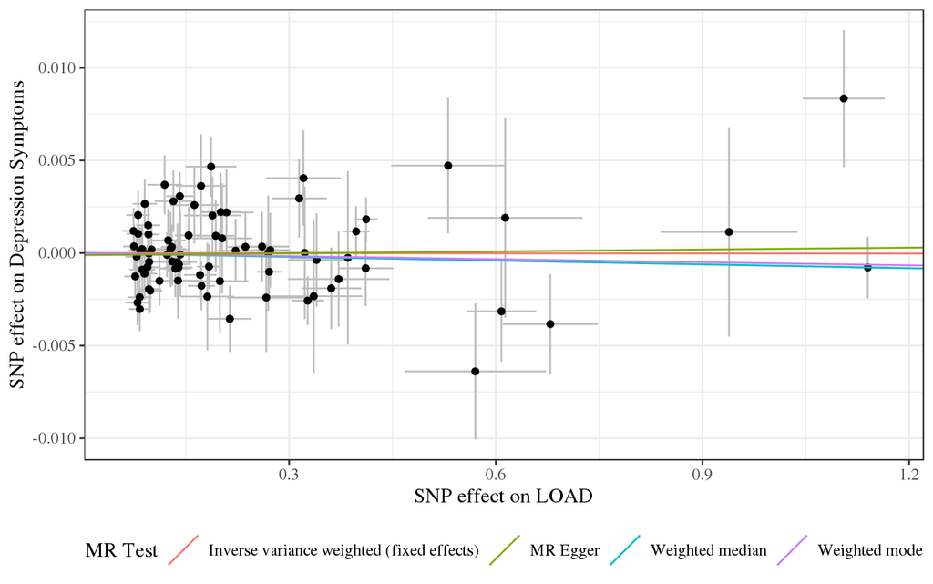